# Estudios de Informática, Multimedia y Telecomunicaciones

# Tipología y ciclo de vida de los datos PRA2

Autor: Alejandro De La Concha

Junio 2020

```r
library(ggplot2)
library(grid)
library(gridExtra)
library (C50)
```

> Utilizaré nuevamente el dataset de censo de EEUU para poder revisar los factores que influyen en el salario, el salario puede ser <=50K USD o >50K

```r
# Cargamos el juego de datos (convertido) de forma local, en lugar de ir a la URL de la PEC1
datosAdult <- read.csv("./adult.data.converted.csv",stringsAsFactors = FALSE, header = FALSE)

# Nombres de los atributos (reducidos de 15 a 11 columnas)
names(datosAdult) <- c("age","workclass","education_num","marital_status","occupation","relationship","race","sex","hour_per_week","native_country","income")
```

> Empezaremos haciendo un breve análisis de los datos ya que nos interesa tener una idea general de los datos que disponemos. Por ello, primero calcularemos las dimensiones de nuestra base de datos y analizaremos qué tipos de atributos tenemos.

```r
dim(datosAdult)
```

```
## [1] 32562    11
```

> En el dataset original: age: representa la edad y es un número entero (mayor a cero). workclass es varable categórica y tiene 9 valores que representa el estado de empleo de la persona. fnlwgt: es un entero que representa el número de registro en el censo, no es útil para nuestro análisis. Education: 16 categorías que muestra el máximo grado de estudios de la persona Education-num: Es un enetero que pone orden de menor a mayor grado de estudio, esta columna está vinculada a la anterior y podría ser redundante. marital-status: 7 categorías, es el estado marital de la persona. occupation: 15 categorías con el tipo de ocupación de la persona. relationship: 6 niveles con el tipo de relación, puede ser redundante con el estado marital. race: 5 tipos, que representan la raza de la persona. sex: 2 tipos, que representan el gñenero de la persona. capital-gain: Número entero con la ganancia en capital, al haber varios con cero, esta columna puede no ser relevante. capital-loss: Parecido al anterior, solo que con la pérdida en capital. hours-per-week: Valor continuo con las horas que trabaja la persona. native-country: 42 valores, representa el país de origen de la persona. income: Si el individuo gana <=50K USD al año o >50K

> ¿Cuáles son esas variables? Gracias a la función str(): age, permanece pero agrupado en grupos <20 años y después grupos de 5 en 5 hasta >75 workclass permanece igual education_num, permanece y se quita education por ser redundante. marital_estatus permanece occupation, permanece relationship, permanece, parecía redundante con marital_estatus, pero más adelante veremos que no podían ser descartados. race y sex permanecen, race se podría simplificar un poco más. hours_per_week, se agrupó en 4: 0 a 20, 20 a 40, 40 y más de 40. native_country, se hicieron varias agrupaciones porque había una cantidad muy alta de países.

```r
#cambiammos a factores para que el algoritmo pueda funcionar
datosAdult$age<-as.factor(datosAdult$age)
datosAdult$workclass<-as.factor(datosAdult$workclass)
datosAdult$education_num<-as.factor(datosAdult$education_num)
datosAdult$marital_status<-as.factor(datosAdult$marital_status)
datosAdult$occupation<-as.factor(datosAdult$occupation)
datosAdult$relationship<-as.factor(datosAdult$relationship)
datosAdult$race<-as.factor(datosAdult$race)
datosAdult$sex<-as.factor(datosAdult$sex)
datosAdult$hour_per_week<-as.factor(datosAdult$hour_per_week)
datosAdult$native_country<-as.factor(datosAdult$native_country)
datosAdult$income<-as.factor(datosAdult$income)

str(datosAdult)
```

```
## 'data.frame':    32562 obs. of  11 variables:
##  $ age           : Factor w/ 13 levels "-20","20-25",..: 13 5 7 5 8 3 5 7 8 4 ...
##  $ workclass     : Factor w/ 10 levels "Federal-gov",..: 10 7 6 4 4 4 4 4 6 4 ...
##  $ education_num : Factor w/ 17 levels "1","10","11",..: 17 5 5 16 14 5 6 12 16 6 ...
##  $ marital_status: Factor w/ 8 levels "Divorced","marital_status",..: 2 6 4 1 4 4 4 5 4 6 ...
##  $ occupation    : Factor w/ 16 levels "Adm-clerical",..: 8 1 4 6 6 11 4 9 4 11 ...
##  $ relationship  : Factor w/ 7 levels "Husband","Not-in-family",..: 5 2 1 2 1 7 7 2 1 2 ...
##  $ race          : Factor w/ 6 levels "Amer-Indian-Eskimo",..: 5 6 6 6 3 3 6 3 6 6 ...
##  $ sex           : Factor w/ 3 levels "Female","Male",..: 3 2 2 2 2 1 1 1 2 1 ...
##  $ hour_per_week : Factor w/ 5 levels "-20","20-40",..: 5 3 1 3 3 3 3 1 4 4 ...
##  $ native_country: Factor w/ 13 levels "Canada","Caribbean",..: 8 11 11 11 11 2 11 2 11 11 ...
##  $ income        : Factor w/ 3 levels "<=50K",">50K",..: 3 1 1 1 1 1 1 1 2 2 ...
```

> Es de gran interés saber si tenemos muchos valores nulos (campos vacíos) y la distribución de valores por variables. Es por ello recomendable empezar el análisis con una visión general de las variables. Mostraremos para cada atributo la cantidad de valores perdidos mediante la función summary.

```r
summary(datosAdult)
```

```
##       age                  workclass     education_num
##  20-25  :4754   Private         :22696   9      :10501
##  30-35  :4353   Self-emp-not-inc: 2541   10     : 7291
##  35-40  :4193   Local-gov       : 2093   13     : 5355
##  25-30  :4161   Unknown         : 1836   14     : 1723
##  40-45  :3816   State-gov       : 1298   11     : 1382
##  45-50  :3167   Self-emp-inc    : 1116   7      : 1175
##  (Other):8118   (Other)         :  982   (Other): 5135
##                marital_status            occupation           relationship
##  Married-civ-spouse   :14976   Prof-specialty :4140   Husband       :13193
##  Never-married        :10683   Craft-repair   :4099   Not-in-family : 8305
##  Divorced             : 4443   Exec-managerial:4066   Other-relative:  981
##  Separated            : 1025   Adm-clerical   :3770   Own-child     : 5068
##  Widowed              :  993   Sales          :3650   relationship  :    1
##  Married-spouse-absent:  418   Other-service  :3295   Unmarried     : 3446
##  (Other)              :   24   (Other)        :9542   Wife          : 1568
##                  race           sex               hour_per_week
##  Amer-Indian-Eskimo:  311   Female:10771   -20           : 1704
##  Asian-Pac-Islander: 1039   Male  :21790   20-40         : 6059
##  Black             : 3124   sex   :    1   40            :15217
##  Other             :  271                  40+           : 9581
##  race              :    1                  hours_per_week:    1
##  White             :27816
##
##                     native_country     income
##  United-States             :29184   <=50K :24720
##  Mexico and Central America:  888   >50K  : 7841
##  Unknown                   :  583   income:    1
##  Western Europe            :  492
##  Caribbean                 :  423
##  South-East Asia           :  400
##  (Other)                   :  592
```

> Vemos que existen valores desconocidos (representados por: Unknown).

> Nos interesa describir la relación entre el salario y cada una de las variables mencionadas anteriormente. Para ello, por un lado graficaremos mediante diagramas de barras la cantidad de personas con salario alto y bajo.

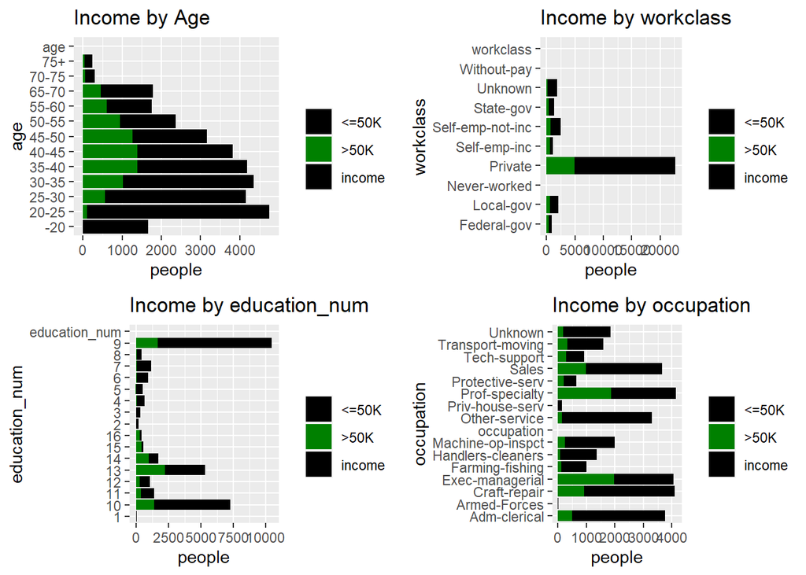

```r
grid.newpage()

plotbyAge2<-ggplot(datosAdult,aes(age,fill=income))+coord_flip() +geom_bar() +labs(x="age", y="people")+ guides(fill=guide_legend(title=""))+ scale_fill_manual(values=c("black","#008000","black","#008000"))+ggtitle("Income by Age")
plotbyworkclass<-ggplot(datosAdult,aes(workclass,fill=income))+coord_flip() +geom_bar() +labs(x="workclass", y="people")+ guides(fill=guide_legend(title=""))+ scale_fill_manual(values=c("black","#008000","black","#008000"))+ggtitle("Income by workclass")
plotbyeducation_num<-ggplot(datosAdult,aes(education_num,fill=income))+coord_flip() +geom_bar() +labs(x="education_num", y="people")+ guides(fill=guide_legend(title=""))+ scale_fill_manual(values=c("black","#008000","black","#008000"))+ggtitle("Income by education_num")
plotbyoccupation<-ggplot(datosAdult,aes(occupation,fill=income))+coord_flip() +geom_bar() +labs(x="occupation", y="people")+ guides(fill=guide_legend(title=""))+ scale_fill_manual(values=c("black","#008000","black","#008000"))+ggtitle("Income by occupation")

grid.arrange(plotbyAge2, plotbyworkclass,plotbyeducation_num,plotbyoccupation,ncol=2)
```

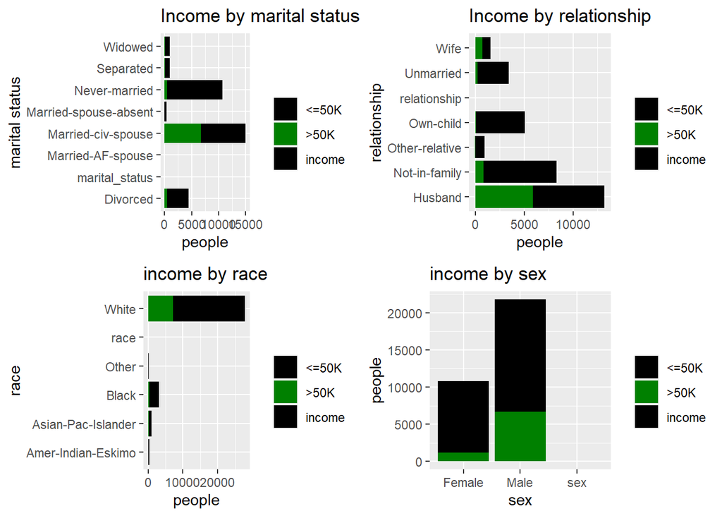

```r
grid.newpage()

plotbymarital_status<-ggplot(datosAdult,aes(marital_status,fill=income))+coord_flip()+geom_bar() +labs(x="marital status", y="people")+ guides(fill=guide_legend(title=""))+ scale_fill_manual(values=c("black","#008000","black","#008000"))+ggtitle("Income by marital status")
plotbyrelationship<-ggplot(datosAdult,aes(relationship,fill=income))+coord_flip()+geom_bar() +labs(x="relationship", y="people")+ guides(fill=guide_legend(title=""))+ scale_fill_manual(values=c("black","#008000","black","#008000"))+ggtitle("Income by relationship")
plotbyrace<-ggplot(datosAdult,aes(race,fill=income))+coord_flip()+geom_bar() +labs(x="race", y="people")+ guides(fill=guide_legend(title=""))+ scale_fill_manual(values=c("black","#008000","black","#008000"))+ggtitle("income by race")
plotbySex2<-ggplot(datosAdult,aes(sex,fill=income))+geom_bar() +labs(x="sex", y="people")+ guides(fill=guide_legend(title=""))+ scale_fill_manual(values=c("black","#008000","black","#008000"))+ggtitle("income by sex")

grid.arrange(plotbymarital_status,plotbyrelationship,plotbyrace,plotbySex2,ncol=2)
```

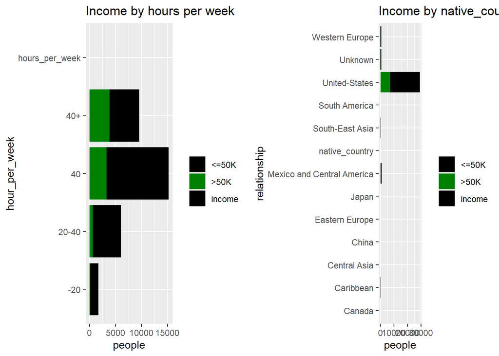

```r
grid.newpage()
plotbyhour_per_week<-ggplot(datosAdult,aes(hour_per_week,fill=income))+coord_flip()+geom_bar() +labs(x="hour_per_week", y="people")+ guides(fill=guide_legend(title=""))+ scale_fill_manual(values=c("black","#008000","black","#008000"))+ggtitle("Income by hours per week")
plotbynative_country<-ggplot(datosAdult,aes(native_country,fill=income))+coord_flip()+geom_bar() +labs(x="relationship", y="people")+ guides(fill=guide_legend(title=""))+ scale_fill_manual(values=c("black","#008000","black","#008000"))+ggtitle("Income by native_country")

grid.arrange(plotbyhour_per_week,plotbynative_country,ncol=2)
```

> De estos gráficos obtenemos información muy valiosa que complementamos con las tablas de contingencia (listadas abajo).

> Hacemos tablas de contingencia de cada variable vs income en el que podemos ver el número de personas y el % que representa por cada agrupación en la variable observada.

```r
tabla_AIT <- table(datosAdult$age,datosAdult$income)
tabla_AIT
```

```
##
##         <=50K >50K income
##   -20    1655    2      0
##   20-25  4642  112      0
##   25-30  3593  568      0
##   30-35  3330 1023      0
##   35-40  2810 1383      0
##   40-45  2425 1391      0
##   45-50  1903 1264      0
##   50-55  1429  942      0
##   55-60  1152  605      0
##   65-70  1335  457      0
##   70-75   245   54      0
##   75+     201   40      0
##   age       0    0      1
```

```r
prop.table(tabla_AIT, margin = 1)
```

```
##
##               <=50K        >50K      income
##   -20   0.998792999 0.001207001 0.000000000
##   20-25 0.976440892 0.023559108 0.000000000
##   25-30 0.863494352 0.136505648 0.000000000
##   30-35 0.764989662 0.235010338 0.000000000
##   35-40 0.670164560 0.329835440 0.000000000
##   40-45 0.635482180 0.364517820 0.000000000
##   45-50 0.600884117 0.399115883 0.000000000
##   50-55 0.602699283 0.397300717 0.000000000
##   55-60 0.655663062 0.344336938 0.000000000
##   65-70 0.744977679 0.255022321 0.000000000
##   70-75 0.819397993 0.180602007 0.000000000
##   75+   0.834024896 0.165975104 0.000000000
##   age   0.000000000 0.000000000 1.000000000
```

> age: el intervalo de edad en el que es más probable tener un salario alto es entre 40 y 60 años.

```r
tabla_WIT <- table(datosAdult$workclass,datosAdult$income)
tabla_WIT
```

```
##
##                    <=50K  >50K income
##   Federal-gov        589   371      0
##   Local-gov         1476   617      0
##   Never-worked         7     0      0
##   Private          17733  4963      0
##   Self-emp-inc       494   622      0
##   Self-emp-not-inc  1817   724      0
##   State-gov          945   353      0
##   Unknown           1645   191      0
##   Without-pay         14     0      0
##   workclass            0     0      1
```

```r
prop.table(tabla_WIT, margin = 1)
```

```
##
##                        <=50K      >50K    income
##   Federal-gov      0.6135417 0.3864583 0.0000000
##   Local-gov        0.7052078 0.2947922 0.0000000
##   Never-worked     1.0000000 0.0000000 0.0000000
##   Private          0.7813271 0.2186729 0.0000000
##   Self-emp-inc     0.4426523 0.5573477 0.0000000
##   Self-emp-not-inc 0.7150728 0.2849272 0.0000000
##   State-gov        0.7280431 0.2719569 0.0000000
##   Unknown          0.8959695 0.1040305 0.0000000
##   Without-pay      1.0000000 0.0000000 0.0000000
##   workclass        0.0000000 0.0000000 1.0000000
```

> workclass: es Private en donde hay más personas pero es self-emp-inc el que más posibilidades tiene de que se acceda a un buen salario mientras que never-worked y without-pay son los que solo tienen salario bajo.

```r
tabla_EnIT <- table(datosAdult$education_num,datosAdult$income)
tabla_EnIT
```

```
##
##                 <=50K >50K income
##   1                51    0      0
##   10             5904 1387      0
##   11             1021  361      0
##   12              802  265      0
##   13             3134 2221      0
##   14              764  959      0
##   15              153  423      0
##   16              107  306      0
##   2               162    6      0
##   3               317   16      0
##   4               606   40      0
##   5               487   27      0
##   6               871   62      0
##   7              1115   60      0
##   8               400   33      0
##   9              8826 1675      0
##   education_num     0    0      1
```

```r
prop.table(tabla_EnIT, margin = 1)
```

```
##
##                      <=50K       >50K     income
##   1             1.00000000 0.00000000 0.00000000
##   10            0.80976546 0.19023454 0.00000000
##   11            0.73878437 0.26121563 0.00000000
##   12            0.75164011 0.24835989 0.00000000
##   13            0.58524743 0.41475257 0.00000000
##   14            0.44341265 0.55658735 0.00000000
##   15            0.26562500 0.73437500 0.00000000
##   16            0.25907990 0.74092010 0.00000000
##   2             0.96428571 0.03571429 0.00000000
##   3             0.95195195 0.04804805 0.00000000
##   4             0.93808050 0.06191950 0.00000000
##   5             0.94747082 0.05252918 0.00000000
##   6             0.93354770 0.06645230 0.00000000
##   7             0.94893617 0.05106383 0.00000000
##   8             0.92378753 0.07621247 0.00000000
##   9             0.84049138 0.15950862 0.00000000
##   education_num 0.00000000 0.00000000 1.00000000
```

> education_num: A mayor educación mayor porcentaje de acceder a un salario alto.

```r
tabla_OIT <- table(datosAdult$occupation,datosAdult$income)
tabla_OIT
```

```
##
##                     <=50K >50K income
##   Adm-clerical       3263  507      0
##   Armed-Forces          8    1      0
##   Craft-repair       3170  929      0
##   Exec-managerial    2098 1968      0
##   Farming-fishing     879  115      0
##   Handlers-cleaners  1284   86      0
##   Machine-op-inspct  1752  250      0
##   occupation            0    0      1
##   Other-service      3158  137      0
##   Priv-house-serv     148    1      0
##   Prof-specialty     2281 1859      0
##   Protective-serv     438  211      0
##   Sales              2667  983      0
##   Tech-support        645  283      0
##   Transport-moving   1277  320      0
##   Unknown            1652  191      0
```

```r
prop.table(tabla_OIT, margin = 1)
```

```
##
##                           <=50K        >50K      income
##   Adm-clerical      0.865517241 0.134482759 0.000000000
##   Armed-Forces      0.888888889 0.111111111 0.000000000
##   Craft-repair      0.773359356 0.226640644 0.000000000
##   Exec-managerial   0.515986227 0.484013773 0.000000000
##   Farming-fishing   0.884305835 0.115694165 0.000000000
##   Handlers-cleaners 0.937226277 0.062773723 0.000000000
##   Machine-op-inspct 0.875124875 0.124875125 0.000000000
##   occupation        0.000000000 0.000000000 1.000000000
##   Other-service     0.958421851 0.041578149 0.000000000
##   Priv-house-serv   0.993288591 0.006711409 0.000000000
##   Prof-specialty    0.550966184 0.449033816 0.000000000
##   Protective-serv   0.674884438 0.325115562 0.000000000
##   Sales             0.730684932 0.269315068 0.000000000
##   Tech-support      0.695043103 0.304956897 0.000000000
##   Transport-moving  0.799624296 0.200375704 0.000000000
##   Unknown           0.896364623 0.103635377 0.000000000
```

> occupation: exec-managerial es la que más posibilidades da de acceder a un salario alto, mientras que priv-house-serv es la que menos.

```r
tabla_MsIT <- table(datosAdult$marital_status,datosAdult$income)
tabla_MsIT
```

```
##
##                         <=50K  >50K income
##   Divorced               3980   463      0
##   marital_status            0     0      1
##   Married-AF-spouse        13    10      0
##   Married-civ-spouse     8284  6692      0
##   Married-spouse-absent   384    34      0
##   Never-married         10192   491      0
##   Separated               959    66      0
##   Widowed                 908    85      0
```

```r
prop.table(tabla_MsIT, margin = 1)
```

```
##
##                              <=50K       >50K     income
##   Divorced              0.89579113 0.10420887 0.00000000
##   marital_status        0.00000000 0.00000000 1.00000000
##   Married-AF-spouse     0.56521739 0.43478261 0.00000000
##   Married-civ-spouse    0.55315171 0.44684829 0.00000000
##   Married-spouse-absent 0.91866029 0.08133971 0.00000000
##   Never-married         0.95403913 0.04596087 0.00000000
##   Separated             0.93560976 0.06439024 0.00000000
##   Widowed               0.91440081 0.08559919 0.00000000
```

> marital_status: married-af-spouse y married-civ-spouse son los de mayor posibilidad de acceder a un salario alto y never-married es la que menos. Hay que tener cuidado aquí con los sesgos.

```r
tabla_RIT <- table(datosAdult$relationship,datosAdult$income)
tabla_RIT
```

```
##
##                  <=50K >50K income
##   Husband         7275 5918      0
##   Not-in-family   7449  856      0
##   Other-relative   944   37      0
##   Own-child       5001   67      0
##   relationship       0    0      1
##   Unmarried       3228  218      0
##   Wife             823  745      0
```

```r
prop.table(tabla_RIT, margin = 1)
```

```
##
##                       <=50K       >50K     income
##   Husband        0.55142879 0.44857121 0.00000000
##   Not-in-family  0.89692956 0.10307044 0.00000000
##   Other-relative 0.96228338 0.03771662 0.00000000
##   Own-child      0.98677979 0.01322021 0.00000000
##   relationship   0.00000000 0.00000000 1.00000000
##   Unmarried      0.93673825 0.06326175 0.00000000
##   Wife           0.52487245 0.47512755 0.00000000
```

> relationship: Los más altos son husband y wife y el más bajo es own-child, que son consistentes con marital_status

```r
tabla_RaIT <- table(datosAdult$race,datosAdult$income)
tabla_RaIT
```

```
##
##                      <=50K  >50K income
##   Amer-Indian-Eskimo   275    36      0
##   Asian-Pac-Islander   763   276      0
##   Black               2737   387      0
##   Other                246    25      0
##   race                   0     0      1
##   White              20699  7117      0
```

```r
prop.table(tabla_RaIT, margin = 1)
```

```
##
##                           <=50K       >50K     income
##   Amer-Indian-Eskimo 0.88424437 0.11575563 0.00000000
##   Asian-Pac-Islander 0.73435996 0.26564004 0.00000000
##   Black              0.87612036 0.12387964 0.00000000
##   Other              0.90774908 0.09225092 0.00000000
##   race               0.00000000 0.00000000 1.00000000
##   White              0.74414006 0.25585994 0.00000000
```

> race: Los de mayor probabilidad de acceder a un salario alto son Asian-Pac-Islander y Withe y other son los que menos. Al estar todos similares, habría que pensar si en bueno incluir esta variable ya que en la realidad puede crear sesgos por raza, si esto se utiliza para acceder a créditos o préstamos, puede ser un mal algoritmo.

```r
tabla_SIT <- table(datosAdult$sex,datosAdult$income)
tabla_SIT
```

```
##
##          <=50K  >50K income
##   Female  9592  1179      0
##   Male   15128  6662      0
##   sex        0     0      1
```

```r
prop.table(tabla_SIT, margin = 1)
```

```
##
##              <=50K      >50K    income
##   Female 0.8905394 0.1094606 0.0000000
##   Male   0.6942634 0.3057366 0.0000000
##   sex    0.0000000 0.0000000 1.0000000
```

> sex: male es el que más posibilidades tiene de acceder a un salario alto, igualmente este podría hacer un sesgo.

```r
tabla_HIT <- table(datosAdult$hour_per_week,datosAdult$income)
tabla_HIT
```

```
##
##                  <=50K  >50K income
##   -20             1587   117      0
##   20-40           5438   621      0
##   40             11970  3247      0
##   40+             5725  3856      0
##   hours_per_week     0     0      1
```

```r
prop.table(tabla_HIT, margin = 1)
```

```
##
##                       <=50K       >50K     income
##   -20            0.93133803 0.06866197 0.00000000
##   20-40          0.89750784 0.10249216 0.00000000
##   40             0.78662023 0.21337977 0.00000000
##   40+            0.59753679 0.40246321 0.00000000
##   hours_per_week 0.00000000 0.00000000 1.00000000
```

> hours_per_week: Los que trabajan poco tienen bajas posibilidades de acceder a un salario alto y los que trabajan mucho tienen más posibilidades.

```r
tabla_NIT <- table(datosAdult$native_country,datosAdult$income)
tabla_NIT
```

```
##
##                              <=50K  >50K income
##   Canada                        82    39      0
##   Caribbean                    368    55      0
##   Central Asia                  85    58      0
##   China                        100    46      0
##   Eastern Europe                20     9      0
##   Japan                         38    24      0
##   Mexico and Central America   836    52      0
##   native_country                 0     0      1
##   South-East Asia              306    94      0
##   South America                 86     4      0
##   United-States              22013  7171      0
##   Unknown                      437   146      0
##   Western Europe               349   143      0
```

```r
prop.table(tabla_NIT, margin = 1)
```

```
##
##                                   <=50K       >50K     income
##   Canada                     0.67768595 0.32231405 0.00000000
##   Caribbean                  0.86997636 0.13002364 0.00000000
##   Central Asia               0.59440559 0.40559441 0.00000000
##   China                      0.68493151 0.31506849 0.00000000
##   Eastern Europe             0.68965517 0.31034483 0.00000000
##   Japan                      0.61290323 0.38709677 0.00000000
##   Mexico and Central America 0.94144144 0.05855856 0.00000000
##   native_country             0.00000000 0.00000000 1.00000000
##   South-East Asia            0.76500000 0.23500000 0.00000000
##   South America              0.95555556 0.04444444 0.00000000
##   United-States              0.75428317 0.24571683 0.00000000
##   Unknown                    0.74957118 0.25042882 0.00000000
##   Western Europe             0.70934959 0.29065041 0.00000000
```

> native_country: Central Asia es el que más posibilidades tiene, aunque hay pocas personas y South America es el que menos. USA es el que tiene más personas registradas.

> Los siguientes gráficos nos permiten visualizar la información mencionada más claramente.

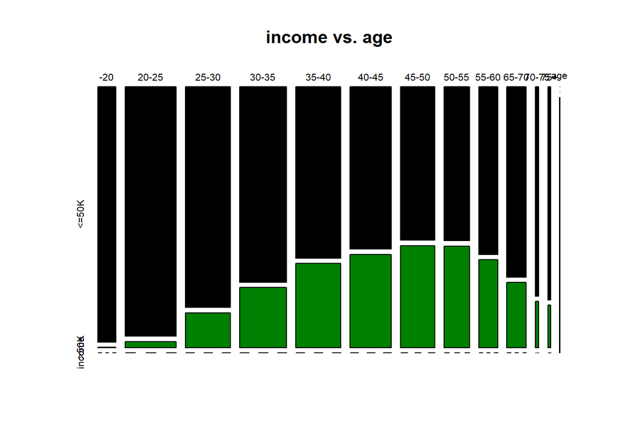

```r
par(mfrow=c(1,1))

plot(tabla_AIT, col = c("black","#008000"), main = "income vs. age")
```

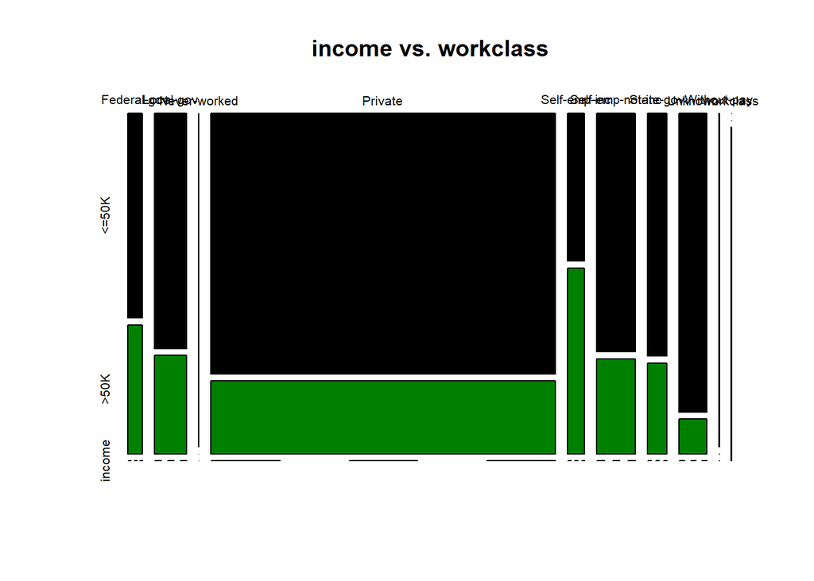

```r
plot(tabla_WIT, col = c("black","#008000"), main = "income vs. workclass")
```

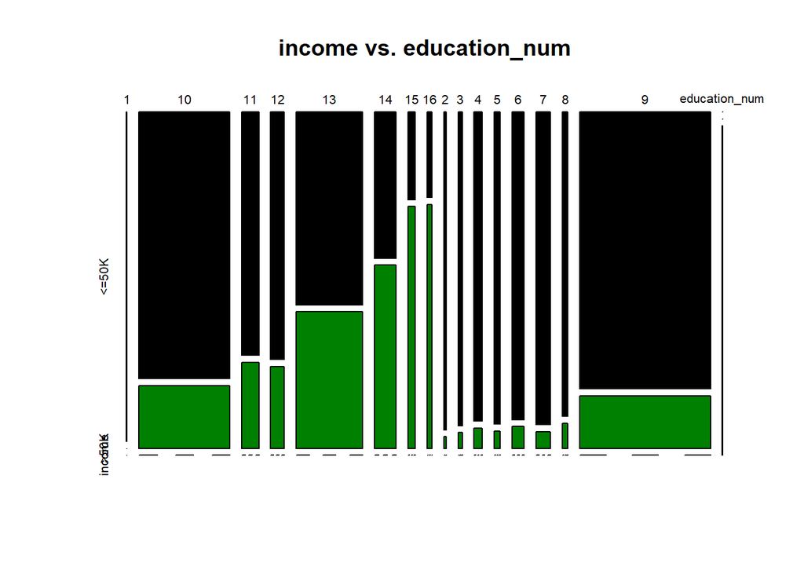

```r
plot(tabla_EnIT, col = c("black","#008000"), main = "income vs. education_num")
```

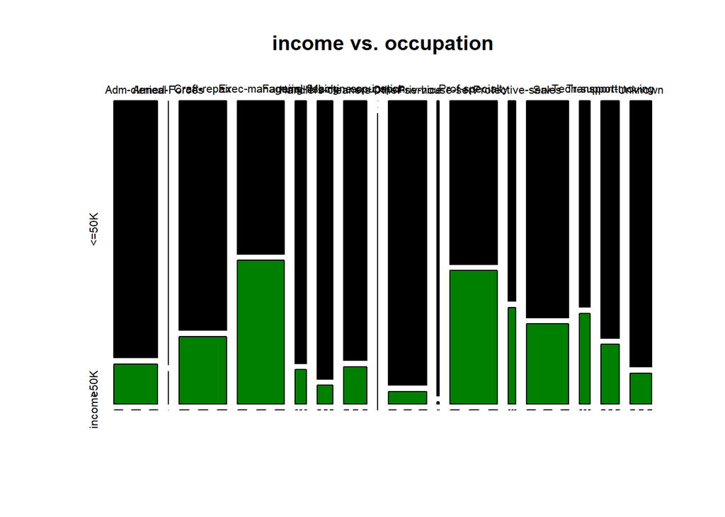

```r
plot(tabla_OIT, col = c("black","#008000"), main = "income vs. occupation")
```

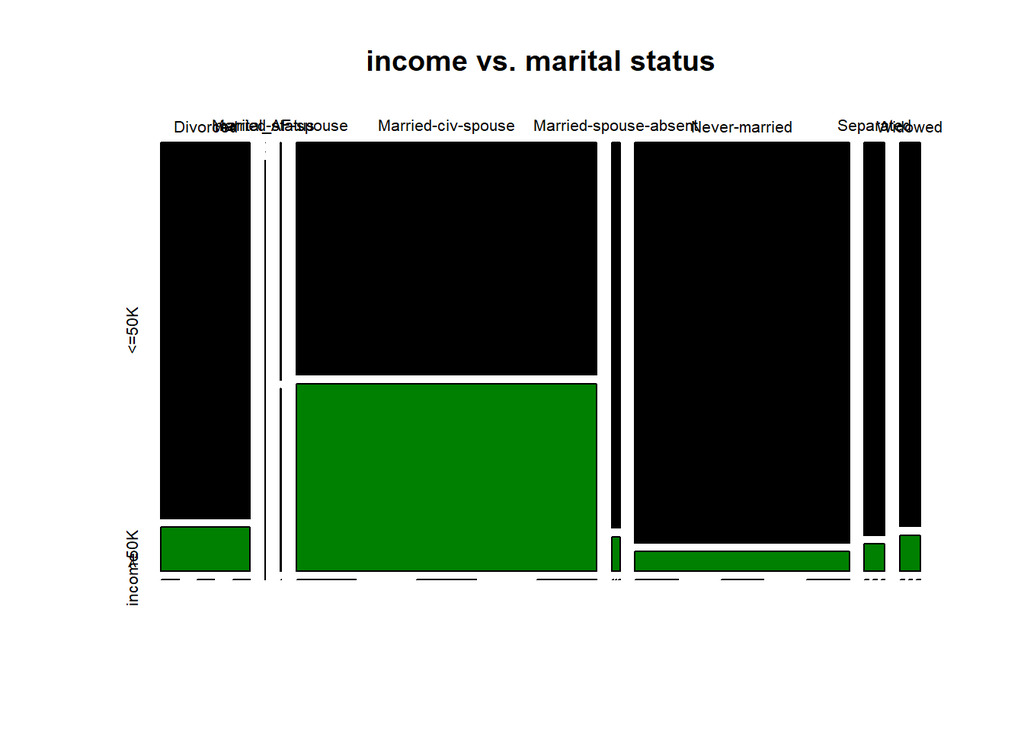

```r
par(mfrow=c(1,1))

plot(tabla_MsIT, col = c("black","#008000"), main = "income vs. marital status")
```

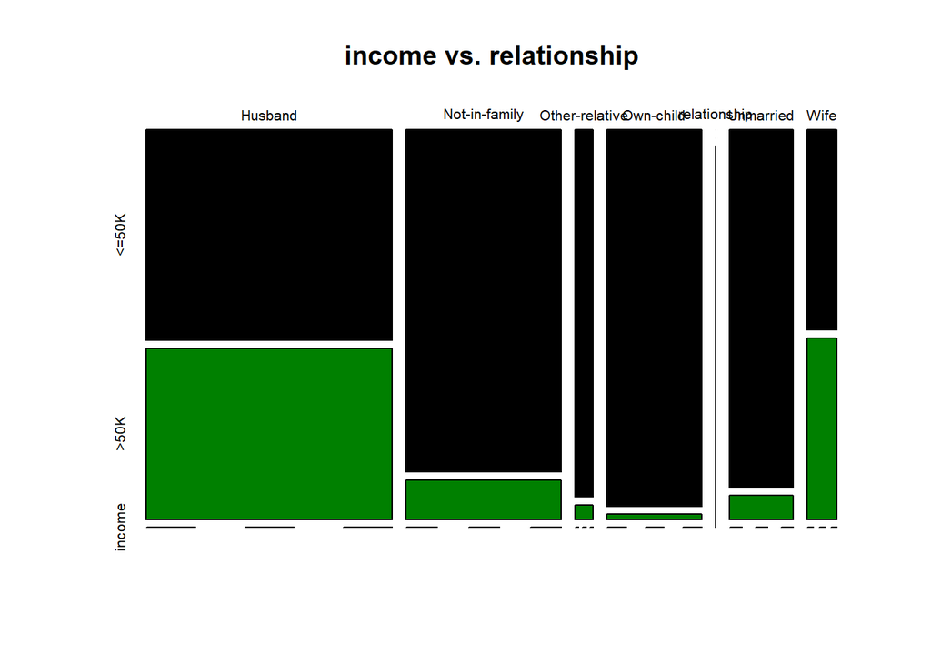

```r
plot(tabla_RIT, col = c("black","#008000"), main = "income vs. relationship")
```

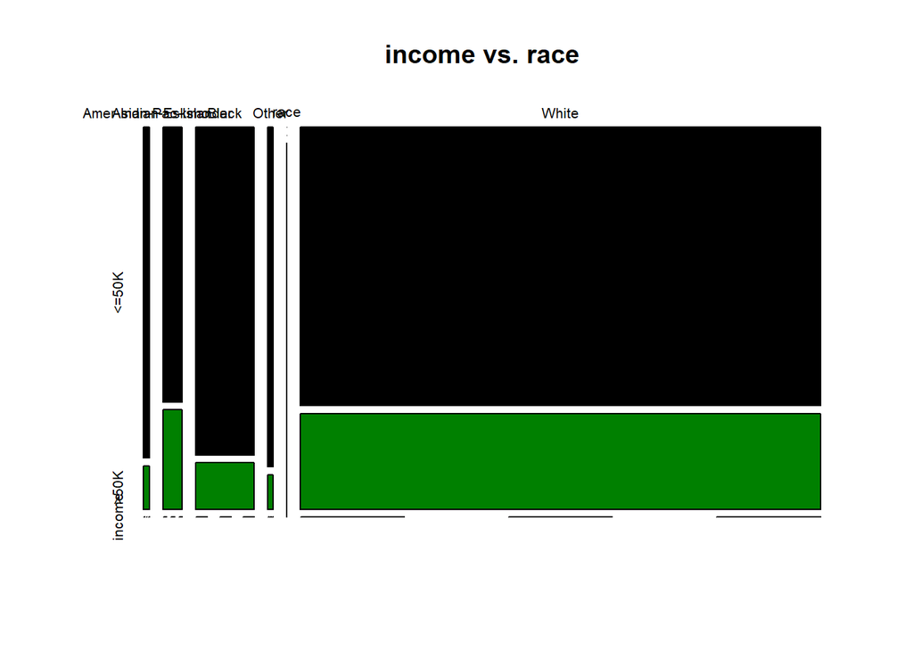

```r
plot(tabla_RaIT, col = c("black","#008000"), main = "income vs. race")
```

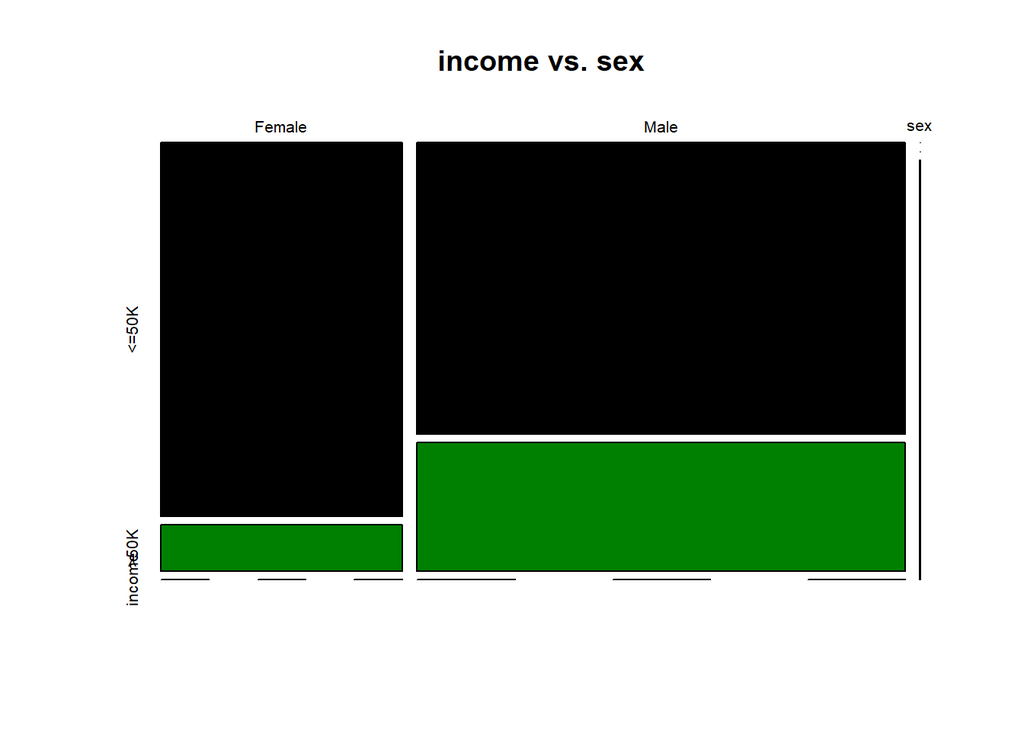

```r
plot(tabla_SIT, col = c("black","#008000"), main = "income vs. sex")
```

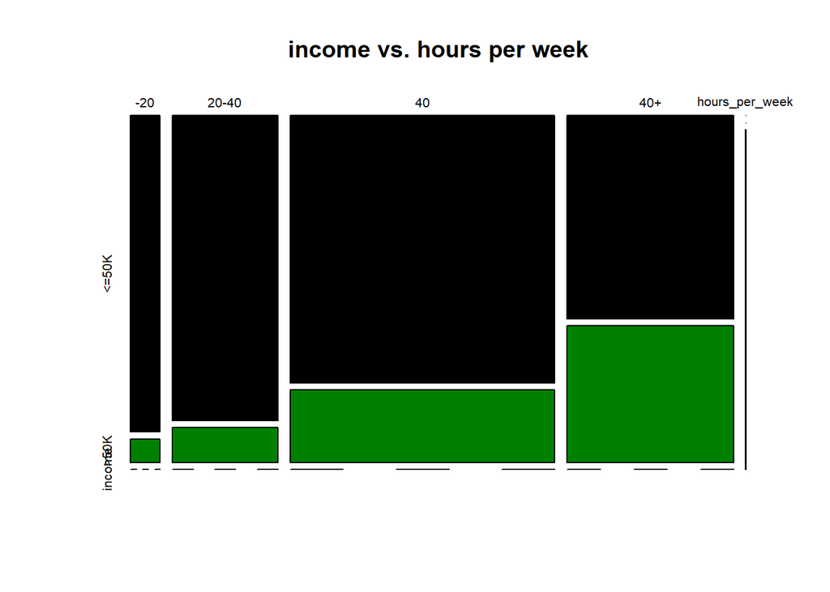

```r
par(mfrow=c(1,1))

plot(tabla_HIT, col = c("black","#008000"), main = "income vs. hours per week")
```

[figure not shown]

```r
plot(tabla_NIT, col = c("black","#008000"), main = "income vs. relationship")
```

> Nuestro objetivo es crear un árbol de decisión que permita analizar qué tipo de persona del censo de EEUU tiene más probabilidades de acceder a un salario alto o no. Por lo tanto, la variable por la que clasificaremos es el campo de income que muestra si el salario e <=50K USD o >50K USD.

```r
head(datosAdult,10)
```

```
##      age        workclass education_num        marital_status        occupation
## 1    age        workclass education_num        marital_status        occupation
## 2  35-40        State-gov            13         Never-married      Adm-clerical
## 3  45-50 Self-emp-not-inc            13    Married-civ-spouse   Exec-managerial
## 4  35-40          Private             9              Divorced Handlers-cleaners
## 5  50-55          Private             7    Married-civ-spouse Handlers-cleaners
## 6  25-30          Private            13    Married-civ-spouse    Prof-specialty
## 7  35-40          Private            14    Married-civ-spouse   Exec-managerial
## 8  45-50          Private             5 Married-spouse-absent     Other-service
## 9  50-55 Self-emp-not-inc             9    Married-civ-spouse   Exec-managerial
## 10 30-35          Private            14         Never-married    Prof-specialty
##     relationship  race    sex  hour_per_week native_country income
## 1   relationship  race    sex hours_per_week native_country income
## 2  Not-in-family White   Male             40  United-States  <=50K
## 3        Husband White   Male            -20  United-States  <=50K
## 4  Not-in-family White   Male             40  United-States  <=50K
## 5        Husband Black   Male             40  United-States  <=50K
## 6           Wife Black Female             40      Caribbean  <=50K
## 7           Wife White Female             40  United-States  <=50K
## 8  Not-in-family Black Female            -20      Caribbean  <=50K
## 9        Husband White   Male            40+  United-States   >50K
## 10 Not-in-family White Female            40+  United-States   >50K
```

```r
tail(datosAdult,10)
```

```
##         age    workclass education_num     marital_status        occupation
## 32553 30-35      Private             6 Married-civ-spouse Handlers-cleaners
## 32554 40-45      Private            11 Married-civ-spouse             Sales
## 32555 30-35      Private            14      Never-married      Tech-support
## 32556 50-55      Private            14 Married-civ-spouse   Exec-managerial
## 32557 20-25      Private            10      Never-married   Protective-serv
## 32558 25-30      Private            12 Married-civ-spouse      Tech-support
## 32559 35-40      Private             9 Married-civ-spouse Machine-op-inspct
## 32560 55-60      Private             9            Widowed      Adm-clerical
## 32561 20-25      Private             9      Never-married      Adm-clerical
## 32562 50-55 Self-emp-inc             9 Married-civ-spouse   Exec-managerial
##        relationship               race    sex hour_per_week native_country
## 32553       Husband Amer-Indian-Eskimo   Male            40  United-States
## 32554       Husband              White   Male           40+  United-States
## 32555 Not-in-family Asian-Pac-Islander   Male           -20          China
```

[output cut: 18 more lines]

> Nos interesará “desordenar” los datos. Guardaremos los datos con el nuevo nombre como “datosAdult_random”.

> Importante: Al ser datos random cada vez, el número de reglas y la precisión, pueden llegar a cambiar con respecto a los valores anotados (sin embargo la variación debe ser poca)

```r
set.seed(1)
datosAdult_random <- datosAdult[sample(nrow(datosAdult)),]
```

> Para la futura evaluación del árbol de decisión, es necesario dividir el conjunto de datos en un conjunto de entrenamiento y un conjunto de prueba. El conjunto de entrenamiento es el subconjunto del conjunto original de datos utilizado para construir un primer modelo; y el conjunto de prueba, el subconjunto del conjunto original de datos utilizado para evaluar la calidad del modelo.

> Lo más correcto será utilizar un conjunto de datos diferente del que utilizamos para construir el árbol, es decir, un conjunto diferente del de entrenamiento. No hay ninguna proporción fijada con respecto al número relativo de componentes de cada subconjunto, pero la más utilizada acostumbra a ser 2/3 para el conjunto de entrenamiento y 1/3, para el conjunto de prueba.

> La variable por la que clasificaremos es el campo de income, que está en la columna 11.

```r
set.seed(666)
yy <- datosAdult_random[,11]
Xx <- datosAdult_random[,1:10]
```

> Podemos elegir el subconjunto de entrenamiento y de prueba de diversas maneras. La primer opción consiste en calcular a cuántas filas corresponde dos tercios de los datos (2*32561/3=21707) y dividir “manualmente” el conjunto. Igualmente si disminuimos o aumentamos el subconjunto podemos obtener distintos resultados, pero si elegimos un subconjunto muy pequeño o uno muy grande corremos el riesgo de hacer un under fitting del modelo si el subconjunto es pequeño, es decir que lo podemos sobre simplificar y por tanto tener poca precisión y si el subconjunto de entrenamiento es muy grande, sería un over fitting el cual se ajustaría mucho a esta realidad pero nuevas entradas que no se parezcan no las podrá predecir correctamente. Para el primer ejemplo vamos con 2/3 del conjunto total.

```r
trainXx <- Xx[1:21707,]
trainyy <- yy[1:21707]
testXx <- Xx[21708:32561,]
testyy <- yy[21708:32561]
```

> En la segunda opción podemos crear directamente un rango. Sin embargo, al no ser un número entero exacto, los resultados entre la opción 1 y 2 son ligeramnete diferentes, dando un poco menos de precisión con el método 2.

```r
indexess = sample(1:nrow(datosAdult), size=floor((2/3)*nrow(datosAdult)))
trainXx<-Xx[indexess,]
trainyy<-yy[indexess]
testXx<-Xx[-indexess,]
testyy<-yy[-indexess]
```

> Después de una extracción aleatoria de casos es altamente recomendable efectuar un análisis de datos mínimo para asegurarnos de no obtener clasificadores sesgados por los valores que contiene cada muestra.

## 0.1 Creación del modelo, calidad del modelo y extracción de reglas

> Se crea el árbol de decisión usando los datos de entrenamiento:

```r
model2 <- C50::C5.0(trainXx, trainyy,rules=TRUE )

summary(model2)
```

```
##
## Call:
## C5.0.default(x = trainXx, y = trainyy, rules = TRUE)
##
##
## C5.0 [Release 2.07 GPL Edition]      Tue Jun 09 18:18:43 2020
## -------------------------------
##
## Class specified by attribute `outcome'
##
## Read 21708 cases (11 attributes) from undefined.data
##
## Rules:
##
## Rule 1: (3312/95, lift 1.3)
##  age in {20-25, 75+}
##  ->  class <=50K  [0.971]
##
## Rule 2: (225/8, lift 1.3)
##  age in {25-30, 30-35, 65-70}
##  native_country = Mexico and Central America
##  ->  class <=50K  [0.960]
##
## Rule 3: (3613/180, lift 1.3)
##  education_num in {1, 10, 11, 12, 2, 3, 4, 5, 6, 7, 8, 9}
##  occupation in {Farming-fishing, Handlers-cleaners, Other-service,
##                        Priv-house-serv}
##  ->  class <=50K  [0.950]
##
## Rule 4: (2533/149, lift 1.2)
##  education_num in {1, 2, 3, 4, 5, 6, 7}
##  ->  class <=50K  [0.941]
##
## Rule 5: (11871/809, lift 1.2)
##  relationship in {Not-in-family, Other-relative, Own-child, Unmarried}
##  ->  class <=50K  [0.932]
##
## Rule 6: (7025/649, lift 1.2)
##  workclass = Private
##  occupation in {Adm-clerical, Craft-repair, Farming-fishing,
```

[output cut: 241 more lines]

```
##
##  Attribute usage:
##
##   88.53% education_num
##   88.50% relationship
##   58.59% hour_per_week
##   58.00% workclass
##   57.30% occupation
##   46.67% age
##   11.46% native_country
##   10.55% race
##    2.21% sex
##
##
## Time: 0.3 secs
```

> Errors muestra el número y porcentaje de casos mal clasificados en el subconjunto de entrenamiento. El árbol obtenido clasifica erróneamente 3407 de los 21707 casos dados, una tasa de error del 15.7%.

> A partir del árbol de decisión que hemos modelado, se pueden extraer las siguientes reglas de decisión (gracias a rules=TRUE podemos imprimir las reglas directamente):

> Ejemplo de como interpretarlas:

> workclass = Private occupation en {Exec-managerial, Handlers-cleaners, Other-service, Protective-serv, Sales, Tech-support} relationship en {Other-relative, Own-child} -> class (income) <=50K 98.8% de validez.

```r
model2 <- C50::C5.0(trainXx, trainyy)

model2
```

```
##
## Call:
## C5.0.default(x = trainXx, y = trainyy)
##
## Classification Tree
## Number of samples: 21708
## Number of predictors: 10
##
## Tree size: 90
##
## Non-standard options: attempt to group attributes
```

[figure not shown]

## 0.2 Validación del modelo con los datos reservados

> Una vez tenemos el modelo, podemos comprobar su calidad prediciendo la clase para los datos de prueba que nos hemos reservado al principio. Que como podemos ver es bastante buena.

```r
predicted_model2 <- predict( model2, testXx, type="class" )
print(sprintf("La precisión del árbol es: %.4f %%",100*sum(predicted_model2 == testyy) / length(predicted_model2)))
```

```
## [1] "La precisión del árbol es: 83.4900 %"
```

> Cuando hay pocas clases (que es el caso actual), la calidad de la predicción se puede analizar mediante una matriz de confusión que identifica los tipos de errores cometidos.

```r
mat_conf2<-table(testyy,Predicted=predicted_model2)
mat_conf2
```

```
##         Predicted
## testyy   <=50K >50K income
##   <=50K   7671  626      0
##   >50K    1166 1391      0
##   income     0    0      0
```

> Otra manera de calcular el porcentaje de registros correctamente clasificados usando la matriz de confusión. La diagonal de superior izquierda a inferior derecha son los resultados correctamente detectados. Arriba a la derecha son personas que en la predicción obtienen un salario alto pero en la realidad es bajo y en la esquina inferior izquierda tienen un salario bajo en la predicción pero en realidad es alto. Aquí la pregunta es: Si tengo que basarme en esta predicción para otorgar un préstamo, qué es peor, negarlo a alguien que tiene el potencial suficiente para pagarlo u otorgarlo a quien no lo podrá pagar? Tal vez lo mejor si ese es el caso es no otrorgarlo a quien lo podrá pagar, es decir, la esquina inferior izquierda. En modelos reales debemos fijarnos en esta consideranción cuando hacemos predicciones para clasificaciones como es el caso.

```r
porcentaje_correct2<-100 * sum(diag(mat_conf2)) / sum(mat_conf2)
print(sprintf("El %% de registros correctamente clasificados es: %.4f %%",porcentaje_correct2))
```

```
## [1] "El % de registros correctamente clasificados es: 83.4900 %"
```

> Además, tenemos a nuestra disposición el paquete gmodels para obtener información más completa:

```r
library (gmodels)

CrossTable(testyy, predicted_model2,prop.chisq  = FALSE, prop.c = FALSE, prop.r =FALSE,dnn = c('Reality', 'Prediction'))
```

```
##
##
##    Cell Contents
## |-------------------------|
## |                       N |
## |         N / Table Total |
## |-------------------------|
##
##
## Total Observations in Table:  10854
##
##
##              | Prediction
##      Reality |     <=50K |      >50K | Row Total |
## -------------|-----------|-----------|-----------|
##        <=50K |      7671 |       626 |      8297 |
##              |     0.707 |     0.058 |           |
## -------------|-----------|-----------|-----------|
##         >50K |      1166 |      1391 |      2557 |
##              |     0.107 |     0.128 |           |
## -------------|-----------|-----------|-----------|
## Column Total |      8837 |      2017 |     10854 |
## -------------|-----------|-----------|-----------|
##
##
```

# 1 Referencias

> Decision Tree, Wikipedia, (https://en.wikipedia.org/wiki/Decision_tree) Confusion Matrix, Wikipedia, (https://en.wikipedia.org/wiki/Confusion_matrix) Visualizing a decision tree using R packages in Explortory (2018), Kei Saito, (https://blog.exploratory.io/visualizing-a-decision-tree-using-r-packages-in-explortory-b26d4cb5e71f) Plot a decision tree, (https://topepo.github.io/C5.0/reference/plot.C5.0.html) C5.0 Classification Models (https://cran.r-project.org/web/packages/C50/vignettes/C5.0.html) Top 5 advantages and disadvantages of Decision Tree Algorithm (2019), Dhiraj K, (https://medium.com/@dhiraj8899/top-5-advantages-and-disadvantages-of-decision-tree-algorithm-428ebd199d9a)